# Random Forests

## Random Forrest Regression

A random forest, like its name implies, consists of a large number of individual decision trees that operate as an ensemble. Each individual tree in the random forest spits out a class prediction and the class with the most votes becomes our model’s prediction.

The prerequisites for random forest to perform well are:

- There needs to be some actual signal in our features so that models built using those features do better than random guessing
- The predictions (and therefore the errors) made by the individual trees need to have low correlations with each other.

##### Ensuring models are diversified

Bagging: Allow each individual tree to randomly sample from the dataset with replacement, resulting in different trees. For example, if our training data was [1, 2, 3, 4, 5, 6] then we might give one of our trees the following list [1, 2, 2, 3, 6, 6].

Random Features: Each tree in a random forest can pick only from a random subset of features. This forces even more variation amongst the trees.

##### Creating Decision Trees

A Decision Tree is a white box type of ML algorithm. It shares internal decision-making logic, which is not available in the black box type of algorithms such as Neural Network. Its training time is faster compared to the neural network algorithm. The time complexity of decision trees is a function of the number of records and number of attributes in the given data. The decision tree is a distribution-free or non-parametric method, which does not depend upon probability distribution assumptions. Decision trees can handle high dimensional data with good accuracy.

Process:

- Select the best attribute using Attribute Selection Measures(ASM) to split the records.
- Make that attribute a decision node and break the dataset into smaller subsets.
- Start tree building by repeating this process recursively for each child until one of the following conditions is satisfied:
  - All the tuples belong to the same attribute value.
  - There are no more remaining attributes.
  - There are no more instances.

##### Attribute Selection Measures

Information Gain: Chooses attribute based on maximum improvement in entropy, compared to parent node, due to split.

Gain Ratio: Improvement on absolute information gain, as number of discrete values of a single feature across data set also considered (e.g. partitioning based on a unique customer_id would be pointless).

Gini Index: Choosing attribute that results in highest sum of class probabilities squared (i.e. lowest gini index which is $1-sum(p_i^2)$)

> Both Scikit-learn and Spark provide information in their documentation on the formulas used for impurity criterion. For classification, they both use Gini impurity by default but offer Entropy as an alternative. For regression, both calculate variance reduction using Mean Square Error. Additionally, variance reduction can be calculated with Mean Absolute Error in Scikit-learn.

##### Online Learning

Batch Learning for Random Forests: Grow forests in batches, with each batch being grown using different data. Ammend batches within forest to update model.

> Mondrian Forests: Made up of Mondrian Trees. A Mondrian Tree, unlike standard Decision tree implementations, does not limit itself to the leaf in making predictions. It takes into account the entire path from the root to the leaf and weighs it according to the distance from the bounding box in that node. This has some interesting properties such as falling back to the prior mean and variance for points far away from the training data.

```python
import numpy as np
import pandas as pd
from sklearn.datasets import load_boston
from matplotlib import pyplot as plt
float_formatter = lambda x: "%.2f" % x
np.set_printoptions(formatter={'float_kind':float_formatter})
from sklearn.ensemble import RandomForestRegressor
from sklearn.model_selection import train_test_split
from sklearn.linear_model import LinearRegression
from sklearn.tree import export_graphviz
from IPython.display import SVG
from graphviz import Source
%matplotlib inline
```

## Aim: Build a random forest model to predict house prices in Boston.

```python
# Loading Boston Housing Data
data = load_boston()
X = data.data
y = data.target
# Storing feature and target names
features = data.feature_names
target = np.array(['MED'])
```

### Preparing and Visualising Data

```python
# Stroing data in pandas dataframe for easier preparation environment
data_df = pd.DataFrame(data=np.column_stack((X,y)),columns=np.append(features, target))
data_df.head()
```

|  | CRIM | ZN | INDUS | CHAS | NOX | RM | AGE | DIS | RAD | TAX | PTRATIO | B | LSTAT | MED |
| --- | --- | --- | --- | --- | --- | --- | --- | --- | --- | --- | --- | --- | --- | --- |
| 0 | 0.00632 | 18.0 | 2.31 | 0.0 | 0.538 | 6.575 | 65.2 | 4.0900 | 1.0 | 296.0 | 15.3 | 396.90 | 4.98 | 24.0 |
| 1 | 0.02731 | 0.0 | 7.07 | 0.0 | 0.469 | 6.421 | 78.9 | 4.9671 | 2.0 | 242.0 | 17.8 | 396.90 | 9.14 | 21.6 |
| 2 | 0.02729 | 0.0 | 7.07 | 0.0 | 0.469 | 7.185 | 61.1 | 4.9671 | 2.0 | 242.0 | 17.8 | 392.83 | 4.03 | 34.7 |
| 3 | 0.03237 | 0.0 | 2.18 | 0.0 | 0.458 | 6.998 | 45.8 | 6.0622 | 3.0 | 222.0 | 18.7 | 394.63 | 2.94 | 33.4 |
| 4 | 0.06905 | 0.0 | 2.18 | 0.0 | 0.458 | 7.147 | 54.2 | 6.0622 | 3.0 | 222.0 | 18.7 | 396.90 | 5.33 | 36.2 |

#### Analysis of Features

```python
print('Shape of input data: {}'.format(X.shape))
print('Shape of target data: {}'.format(y.shape))
print('List of features: {}'.format(features))
print('Target name: {}'.format(target))
```

```
Shape of input data: (506, 13)
Shape of target data: (506,)
List of features: ['CRIM' 'ZN' 'INDUS' 'CHAS' 'NOX' 'RM' 'AGE' 'DIS' 'RAD' 'TAX' 'PTRATIO'
 'B' 'LSTAT']
Target name: ['MED']
```

- CRIM per capita crime rate by town
- ZN proportion of residential land zoned for lots over 25,000 sq.ft.
- INDUS proportion of non-retail business acres per town
- CHAS Charles River dummy variable (= 1 if tract bounds river; 0 otherwise)
- NOX nitric oxides concentration (parts per 10 million)
- RM average number of rooms per dwelling
- AGE proportion of owner-occupied units built prior to 1940
- DIS weighted distances to five Boston employment centres
- RAD index of accessibility to radial highways
- TAX full-value property-tax rate per \$10,000
- PTRATIO pupil-teacher ratio by town
- B 1000(Bk - 0.63)^2 where Bk is the proportion of blacks by town
- LSTAT \% lower status of the population
- MED Median value of owner-occupied homes in $1000’s

```python
print('Data type for each column:\n{}'.format(data_df.dtypes))
```

```
Data type for each column:
CRIM       float64
ZN         float64
INDUS      float64
CHAS       float64
NOX        float64
RM         float64
AGE        float64
DIS        float64
RAD        float64
TAX        float64
PTRATIO    float64
B          float64
LSTAT      float64
MED        float64
dtype: object
```

```python
[print('Unique Values for {}: {}'.format(col, len(data_df[col].unique().tolist()))) for col in features]
pass
```

```
Unique Values for CRIM: 504
Unique Values for ZN: 26
Unique Values for INDUS: 76
Unique Values for CHAS: 2
Unique Values for NOX: 81
Unique Values for RM: 446
Unique Values for AGE: 356
Unique Values for DIS: 412
Unique Values for RAD: 9
Unique Values for TAX: 66
Unique Values for PTRATIO: 46
Unique Values for B: 357
Unique Values for LSTAT: 455
```

```python
print('Number of duplicate rows: {}'.format(len(data_df[data_df.duplicated(keep='first')])))
```

```
Number of duplicate rows: 0
```

Having erroneous duplicate rows in a random forest model can impact the accuracy of the model as if the probability of a data point is greater than its actual value, the bagged selection of datapoints which are used to train individual trees will not be representative of the population.

```python
print('Missing values in data across columns: {}'.format(sum([data_df[col].isna().sum() for col in features])))
```

```
Missing values in data across columns: 0
```

No missing values exist in this dataset however, if there were missing values, random forests could be used to impute these missing values. For example, one could create a forest of trees based on attributes for which there are few missing values across all feature vectors. Subsequently, the trees can be used to identify complete feature vectors that are in close proximity to feature vectors with missing values. Thus, missing values for a particualr attribute can be estimated based on corresponding values in vectors that are nearby.

```python
# Data statistics
data_df.describe()
```

|  | CRIM | ZN | INDUS | CHAS | NOX | RM | AGE | DIS | RAD | TAX | PTRATIO | B | LSTAT | MED |
| --- | --- | --- | --- | --- | --- | --- | --- | --- | --- | --- | --- | --- | --- | --- |
| count | 506.000000 | 506.000000 | 506.000000 | 506.000000 | 506.000000 | 506.000000 | 506.000000 | 506.000000 | 506.000000 | 506.000000 | 506.000000 | 506.000000 | 506.000000 | 506.000000 |
| mean | 3.613524 | 11.363636 | 11.136779 | 0.069170 | 0.554695 | 6.284634 | 68.574901 | 3.795043 | 9.549407 | 408.237154 | 18.455534 | 356.674032 | 12.653063 | 22.532806 |
| std | 8.601545 | 23.322453 | 6.860353 | 0.253994 | 0.115878 | 0.702617 | 28.148861 | 2.105710 | 8.707259 | 168.537116 | 2.164946 | 91.294864 | 7.141062 | 9.197104 |
| min | 0.006320 | 0.000000 | 0.460000 | 0.000000 | 0.385000 | 3.561000 | 2.900000 | 1.129600 | 1.000000 | 187.000000 | 12.600000 | 0.320000 | 1.730000 | 5.000000 |
| 25% | 0.082045 | 0.000000 | 5.190000 | 0.000000 | 0.449000 | 5.885500 | 45.025000 | 2.100175 | 4.000000 | 279.000000 | 17.400000 | 375.377500 | 6.950000 | 17.025000 |
| 50% | 0.256510 | 0.000000 | 9.690000 | 0.000000 | 0.538000 | 6.208500 | 77.500000 | 3.207450 | 5.000000 | 330.000000 | 19.050000 | 391.440000 | 11.360000 | 21.200000 |
| 75% | 3.677083 | 12.500000 | 18.100000 | 0.000000 | 0.624000 | 6.623500 | 94.075000 | 5.188425 | 24.000000 | 666.000000 | 20.200000 | 396.225000 | 16.955000 | 25.000000 |
| max | 88.976200 | 100.000000 | 27.740000 | 1.000000 | 0.871000 | 8.780000 | 100.000000 | 12.126500 | 24.000000 | 711.000000 | 22.000000 | 396.900000 | 37.970000 | 50.000000 |

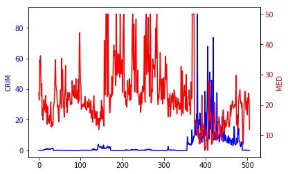

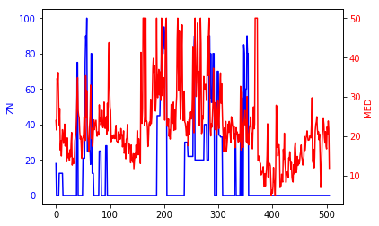

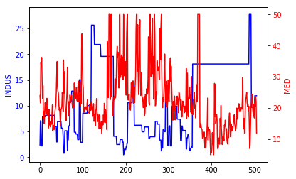

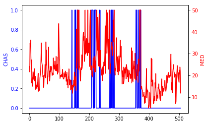

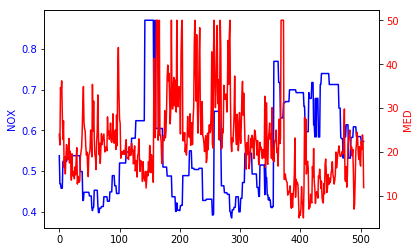

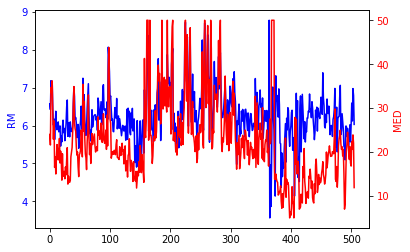

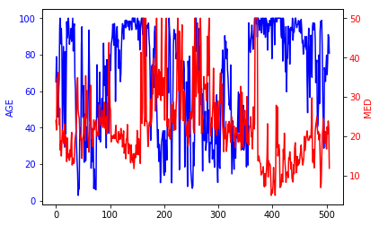

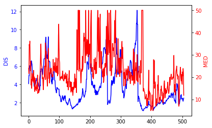

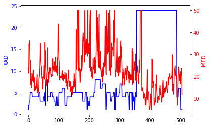

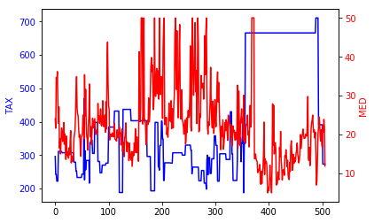

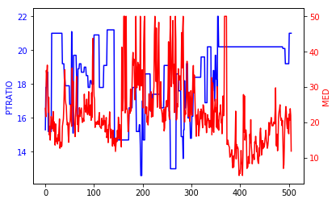

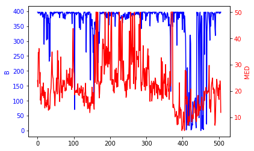

[1 more figures not shown]

```python
# Data Visualisation

# Storing indicies in list for x-axis reference
indicies = data_df.index.values.tolist()

# Plotting comparative plot between each feature and target
for i, col in enumerate(data_df.columns.tolist()[:-1]):
    fig, axs = plt.subplots()
    axs.plot(indicies, data_df[col], color='blue')
    axs.set_ylabel(col, color='blue')
    axs.tick_params(axis='y', labelcolor='blue')
    axs2 = axs.twinx()
    axs2.plot(indicies, data_df[target[0]], color='red')
    axs2.set_ylabel(target[0], color='red')
    axs2.tick_params(axis='y', labelcolor='red')
```

All values within each feature vector fall within appropriate ranges, as defined by the description of each feature. This can be seen in both the data's summary and visualisations of the values that correspond to each feature. The visualisations also give us an indication of the features that might most important in determining house prices (e.g. Average number of rooms per dwelling).

#### Splitting Data

```python
X_tr, X_te, y_tr, y_te = train_test_split(X, y, test_size = 0.25, random_state = 42)
print('Training Features Shape: {}'.format(X_tr.shape))
print('Test Features Shape: {}'.format(X_te.shape))
print('Training Labels Shape: {}'.format(y_tr.shape))
print('Test Features Shape: {}'.format(y_te.shape))
```

```
Training Features Shape: (379, 13)
Test Features Shape: (127, 13)
Training Labels Shape: (379,)
Test Features Shape: (127,)
```

### Baseline Model

Given the patterns observed in the visualisations above, we can propose a simple regression model between the average number of rooms per dwelling and median prices, as the baseline to beat.

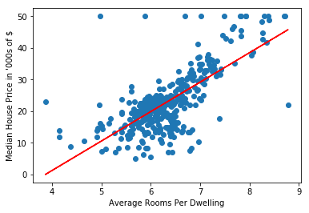

```
Accuracy for Test Set: 90.02%
```

```python
# Extracting RM column from dataframe for training and test set.
X_reg_tr = X_tr[:,features.tolist().index('RM')].reshape(-1,1)
X_reg_te = X_te[:,features.tolist().index('RM')].reshape(-1,1)

# Linear regression model based on training set
reg = LinearRegression().fit(X_reg_tr, y_tr)
plt.scatter(X_reg_tr, y_tr)
plt.plot(X_reg_tr, reg.predict(X_reg_tr), color='red')
plt.xlabel('Average Rooms Per Dwelling')
plt.ylabel('Median House Price in \'000s of $')
plt.show()

# Accuracy for the model determined by predicting output based on test set
print('Accuracy for Test Set: {}%'.format(round(100 - np.mean(100 * ((reg.predict(X_reg_te) - y_te)/y_te)), 2)))
```

### Random Forest Model

```python
# Instantiate model with 1000 decision trees
rf = RandomForestRegressor(n_estimators = 1000, random_state = 42)
# Train the model on training data
rf.fit(X_tr, y_tr);
# Use the forest's predict method on the test data
predictions = rf.predict(X_te)
# Print out the accuracy
print('Accuracy for Test Set: {}%'.format(round(100 - np.mean(100 * ((predictions - y_te)/y_te)), 2)))
```

```
Accuracy for Test Set: 98.5%
```

```python
# Get numerical feature importances
importances = list(rf.feature_importances_)
# List of tuples with variable and importance
feature_importances = [(feature, round(importance, 2)) for feature, importance in zip(features, importances)]
# Sort the feature importances by most important first
feature_importances = sorted(feature_importances, key = lambda x: x[1], reverse = True)
# Print out the feature and importances
[print('Variable: {:20} Importance: {}'.format(*pair)) for pair in feature_importances];
```

```
Variable: RM                   Importance: 0.44
Variable: LSTAT                Importance: 0.38
Variable: DIS                  Importance: 0.06
Variable: CRIM                 Importance: 0.04
Variable: AGE                  Importance: 0.02
Variable: PTRATIO              Importance: 0.02
Variable: INDUS                Importance: 0.01
Variable: NOX                  Importance: 0.01
Variable: TAX                  Importance: 0.01
Variable: B                    Importance: 0.01
Variable: ZN                   Importance: 0.0
Variable: CHAS                 Importance: 0.0
Variable: RAD                  Importance: 0.0
```

```python
# Pull out one tree from the forest
tree = rf.estimators_[5]
graph = Source(export_graphviz(tree, out_file=None, feature_names=features))
SVG(graph.pipe(format='svg'))
```

[figure not shown]

```python
# Instantiate model with 500 decision trees
rf = RandomForestRegressor(n_estimators = 500, random_state = 42)
# Train the model on training data
rf.fit(X_tr, y_tr);
# Use the forest's predict method on the test data
predictions = rf.predict(X_te)
# Print out the accuracy
print('Accuracy for Test Set: {}%'.format(round(100 - np.mean(100 * ((predictions - y_te)/y_te)), 2)))
```

```
Accuracy for Test Set: 98.54%
```

```python
# Get numerical feature importances
importances = list(rf.feature_importances_)
# List of tuples with variable and importance
feature_importances = [(feature, round(importance, 2)) for feature, importance in zip(features, importances)]
# Sort the feature importances by most important first
feature_importances = sorted(feature_importances, key = lambda x: x[1], reverse = True)
# Print out the feature and importances
[print('Variable: {:20} Importance: {}'.format(*pair)) for pair in feature_importances];
```

```
Variable: RM                   Importance: 0.44
Variable: LSTAT                Importance: 0.38
Variable: DIS                  Importance: 0.06
Variable: CRIM                 Importance: 0.04
Variable: AGE                  Importance: 0.02
Variable: PTRATIO              Importance: 0.02
Variable: INDUS                Importance: 0.01
Variable: NOX                  Importance: 0.01
Variable: TAX                  Importance: 0.01
Variable: B                    Importance: 0.01
Variable: ZN                   Importance: 0.0
Variable: CHAS                 Importance: 0.0
Variable: RAD                  Importance: 0.0
```

```python
# Instantiate model with 250 decision trees
rf = RandomForestRegressor(n_estimators = 250, random_state = 42)
# Train the model on training data
rf.fit(X_tr, y_tr);
# Use the forest's predict method on the test data
predictions = rf.predict(X_te)
# Print out the accuracy
print('Accuracy for Test Set: {}%'.format(round(100 - np.mean(100 * ((predictions - y_te)/y_te)), 2)))
```

```
Accuracy for Test Set: 98.45%
```

```python
# Get numerical feature importances
importances = list(rf.feature_importances_)
# List of tuples with variable and importance
feature_importances = [(feature, round(importance, 2)) for feature, importance in zip(features, importances)]
# Sort the feature importances by most important first
feature_importances = sorted(feature_importances, key = lambda x: x[1], reverse = True)
# Print out the feature and importances
[print('Variable: {:20} Importance: {}'.format(*pair)) for pair in feature_importances];
```

```
Variable: RM                   Importance: 0.45
Variable: LSTAT                Importance: 0.37
Variable: DIS                  Importance: 0.06
Variable: CRIM                 Importance: 0.04
Variable: PTRATIO              Importance: 0.02
Variable: INDUS                Importance: 0.01
Variable: NOX                  Importance: 0.01
Variable: AGE                  Importance: 0.01
Variable: RAD                  Importance: 0.01
Variable: TAX                  Importance: 0.01
Variable: B                    Importance: 0.01
Variable: ZN                   Importance: 0.0
Variable: CHAS                 Importance: 0.0
```

```python
# Instantiate model with 500 decision trees and max depth of tree restricted to 3
rf = RandomForestRegressor(n_estimators = 500, random_state = 42, max_depth=3)
# Train the model on training data
rf.fit(X_tr, y_tr);
# Use the forest's predict method on the test data
predictions = rf.predict(X_te)
# Print out the accuracy
print('Accuracy for Test Set: {}%'.format(round(100 - np.mean(100 * ((predictions - y_te)/y_te)), 2)))
```

```
Accuracy for Test Set: 94.78%
```

```python
# Get numerical feature importances
importances = list(rf.feature_importances_)
# List of tuples with variable and importance
feature_importances = [(feature, round(importance, 2)) for feature, importance in zip(features, importances)]
# Sort the feature importances by most important first
feature_importances = sorted(feature_importances, key = lambda x: x[1], reverse = True)
# Print out the feature and importances
[print('Variable: {:20} Importance: {}'.format(*pair)) for pair in feature_importances];
```

```
Variable: RM                   Importance: 0.47
Variable: LSTAT                Importance: 0.43
Variable: DIS                  Importance: 0.05
Variable: CRIM                 Importance: 0.03
Variable: PTRATIO              Importance: 0.01
Variable: ZN                   Importance: 0.0
Variable: INDUS                Importance: 0.0
Variable: CHAS                 Importance: 0.0
Variable: NOX                  Importance: 0.0
Variable: AGE                  Importance: 0.0
Variable: RAD                  Importance: 0.0
Variable: TAX                  Importance: 0.0
Variable: B                    Importance: 0.0
```

```python
# Pull out one tree from the forest
tree = rf.estimators_[5]
graph = Source(export_graphviz(tree, out_file=None, feature_names=features))
SVG(graph.pipe(format='svg'))
```

[figure not shown]

```python
# Instantiate model with 500 decision trees and max depth of tree restricted to 6
rf = RandomForestRegressor(n_estimators = 500, random_state = 42, max_depth=6)
# Train the model on training data
rf.fit(X_tr, y_tr);
# Use the forest's predict method on the test data
predictions = rf.predict(X_te)
# Print out the accuracy
print('Accuracy for Test Set: {}%'.format(round(100 - np.mean(100 * ((predictions - y_te)/y_te)), 2)))
```

```
Accuracy for Test Set: 97.93%
```

```python
# Instantiate model with 500 decision trees and max depth of tree restricted to 7
rf = RandomForestRegressor(n_estimators = 500, random_state = 42, max_depth=7)
# Train the model on training data
rf.fit(X_tr, y_tr);
# Use the forest's predict method on the test data
predictions = rf.predict(X_te)
# Print out the accuracy
print('Accuracy for Test Set: {}%'.format(round(100 - np.mean(100 * ((predictions - y_te)/y_te)), 2)))
```

```
Accuracy for Test Set: 98.09%
```

#### Conclusion

The fact that the model performs well on the test set is an indication that it could generalise well to new data. However, this will depend on how representative this data is of the larger population. Above, we see that the best results are obtained when an ensemble of 500 trees are used in the model. For this dataset, the margin of difference between the performance of models with different ensemble sizes is minimal. Generally, the greater the number of trees the less correlation there is between the predictions of each tree, thus resulting in models that are more resistant to overfitting on training data. The only down side to a greater number of trees is the time required to train the model. The maximum depth of trees within a random forest model is another hyperparameter that can be tuned to improve results. Generally, a model in which tree depth is unrestricted could be more prone to overfitting on the training set. However, in the case above we observe that increasing the tree depth only results in greater accuracy of the model when applied on the test set. A more in depth cross validation exercise with more data, across more values of the hyperparameter, could be conducted to better understand the role of tree depth.

Often random forest models out perform other methods such as neural networks, however this is generally only true for tabular data. A limitation of the random forest regression model that is that it cannot predict values outside of the range of the data that was used to train the model. A benefit is that a random forest model can still be trained on data with missing values as not all trees consider all features during training. The number of variations and hyperparameters in neural networks means that while they have the potential to outperform random forest models, a large amount of time and effort is required to do this, as data requires greater pre-processing and more hyperparameters exist that need to be tuned.

###### Sources:

> https://towardsdatascience.com/understanding-random-forest-58381e0602d2  
> https://towardsdatascience.com/random-forest-in-python-24d0893d51c0  
> https://medium.com/@srnghn/the-mathematics-of-decision-trees-random-forest-and-feature-importance-in-scikit-learn-and-spark-f2861df67e3  
> https://medium.com/all-things-ai/in-depth-parameter-tuning-for-random-forest-d67bb7e920d  
> https://blog.frankfurt-school.de/wp-content/uploads/2018/10/Neural-Networks-vs-Random-Forests.pdf  
> https://papers.nips.cc/paper/5234-mondrian-forests-efficient-online-random-forests.pdf  
> https://medium.com/mlrecipies/mondrian-forests-making-random-forests-better-and-efficient-b27814c681e5